# slippery_hill_statistics

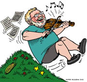

Slippery-Hill Statistics  
Sean Franco  
December, 2025

## Introduction

Slippery-Hill offers a robust collection of educational resources and archival preservation of oldtime fiddling traditions largely of the United States. This analysis is an exploratory analysis of oldtime fiddle tunes on Slippery-Hill. The Slippery-Hill team is excited to showcase a data science perspective of oldtime fiddle tunes as the site stands snapshotted December 2025. The study examines tunings, keys, artists, and geographic visualizations of oldtime fiddle tunes. This study excludes Slippery-Hill’s 78 collection, and other resources for learning materials and festival information.

## Methodology

### Tuning

Overall Slippery-Hill documents and categorizes fiddle tunes by tuning, and key. Slippery-Hill attempts to document unusual tunings, as well as categorize tunings in a meaningful way. Most tunings on the site are labled in reference to “A” 440Hz. The categorization is attributed based on the string relationship, rather than actual pitch. For example, a tune in “GDGD” tuning would be categorized in this analysis as “AEAE” in the “A” 440Hz tuning orientation. Consolidation of relatively pitched fiddle tunings better represent tunes that share the core string relationships.

### Key

Slippery-Hill includes many fiddle tunes that have many keys and tonality. Like tunings, keys are also relatively categorized to “A” 440Hz. For example, If a tune is relatively equivalent to the key of “G” in “GDAE” tuning then it would take these labels regardless of pitch. This study also categorizes based on relative tonal relationships between tunes that change keys using a modified roman numeral chord symbols. For example, a starting key of “G” or G major is represented by the capital roman numeral “I” which indicates any typical major scale. This principle also applies to tunes with tonal shifts such as a tune with a starting key of “G”, and a “I-V” relationship representing a “G & D” tune. The logic being that D is the fifth tone of the G major scale, and the key change is also major. Additionally, tunes with more than two keys are related in terms of the starting key. A starting key of “D” and “I-IV-V” represents a “D & G & A” tune.

Lowercase numerals indicate minor keys. For example, a starting key of “A” in “A minor & C” is represented as “i-III”. The first key is minor and in lower-case numerals, and the following key (in reference to the first key) is the 3rd tone of the A scale represented as C major. Of course, these keys are open to interpretation. In this example, tin-pan-alley, and ragtime key changes are possibly at play, as well as an alternative interpretation where C is the starting key tonality as the tune shifts to a vi or minor 6th scale tone. However, on Slippery-Hill this example corresponds to 3 counts of “Rutland’s Reel”, and 1 count of “Eli Green’s Cakewalk” both of which favor the former interpretation.

Another common key or tonality distinction in oldtime music is modal tunes. Modal tunes are tunes with ambiguous root tonality, and their tonality can be greatly influenced by the choice of chordal accompaniment. Modal tunes are represented with the asterisk (*) symbol placed at the end of the starting key roman numeral.

The table below showcases an example of the naming schema.

| Starting Key | Relative Key | Actual Keys |
| --- | --- | --- |
| G | I | G |
| G | I-V | G & D |
| D | I-IV-V | D & G & A |
| A | i-III | A minor & C |
| E | I* | E Modal |

### Geographic Determination Methodology

Manual research was conducted to determine an artist’s county and state information which are used to produce maps in this study. People travel, and change residences, so the determination of each county and state is based on duration of residence. Oddly enough, most artists on Slippery-Hill tended to be born in nearby counties with no further records residence changes at increased distances. For example Tommy Jarrell lived a large duration of his life in Surry county, North Carolina. This methodology of residence duration also captures nuance robustly. For example, Ward Jarvis was born and raised in Calhoun County, West Virginia where he developed his musical journey rooted in West Virginia repertoire and style. However in the late 1940s Ward Jarvis changed residence to nearby Athens County, Ohio where he lived for a larger duration of his life. Fair questions arise about originating styles and repertoires for county to county, and state to state transplants. In a humanistic viewpoint, people bring culture with them and dynamically change (to a degree) based on where they call home, and community. This study attributes location to capture this principle as best as possible.

Career musicians tended to have residence changes at greater distances. The prevailing characteristic being these musicians started their musical journey in a (usually small, and rural) community, then as they developed their musical career traveled to urban centers. For example, Roy Odell “Speedy” Tolliver, was born and raised in southwest Virginia in the early 1910s who then later moved and resided in the greater Washington, DC metro area.

The research methodology included queries in the form of: *“{artist name}” county fiddle*. The quotes on the artist name specify artists that directly match to Slippery-Hill’s collection. Trusted resources include but are not limited to 78 metadata databases (i78, Discography of American Historical Recordings (DAHR)), other oldtime, North American fiddle collection websites, digitized county records, university digital collections etc. Verification of identity of the artist between the entries in Slippery-Hill’s collection and the potential resource were a first step before accepting the information of the resource in question. Once it is verified that the artist mentioned in the resource is the same as in Slippery-Hill’s collection, then the second step is to evaluate the level of accuracy of the potential resource. University or affiliated collections or academic research incurred a high level of trust in the resource, whereas personal (especially non fiddle or music related blogs) incurred lower levels of trust. Resources with the highest level of trust were used to at least confirm an artists associated state. As mentioned earlier, it was surprising that most artist were able to be identified to a county and state of longest residential duration.

All artists (excluding 33 unknown artist names) were sourced and attributed to a state. Around 50 artists were not able to be determined at the county level. For these artists a flag variable was created, (to indicate no county-level information could be found) and the county for that artist’s state was attributed to them to ensure inclusion in the maps. The assumption follows existing trends of musicians being located in urbanized or reasonably develop population centers. This is an easier assumption to maintain rather than collect time series population data, specific decades for each artist of residence to map to population densities for these entries.

The maps utilize the 2020 census county shapes which are largely unaffected for artists born during this study. Additionally, artist points were ‘jittered’ a tad for visualization purposes. Thus, some artists might not neatly be placed in their county boarder.

# Visualizations

## Tuning Distribution

[interactive chart not shown]

The above plot showcases the counts and percentages of distinct tunings housed on Slippery-Hill. Tunings that are relatively pitched, but retain the same string relationships such as “AEAE” and “GDGD” were consolidated into A 440Hz orientation.

Overall “GDAE” (and relative) tunings are the most common on Slippery-Hill. This makes sense since this tuning supports playing in multiple keys, and is observed as standard, Italian tuning.

## Key Distribution

[interactive chart not shown]

These plots shows a tune’s starting key (on the x-axis), and the counts of relative keys. See the introduction for interpretation of the key symbology.

As observed in the plots, most tunes on Slippery-Hill are rooted in the major keys with no key changes. The key of “G” is the most common key for the “I” symbol. The next common relative key is “I*” where the astrict notes modal tunes. Modal tunes are tunes with ambiguous tonality. The starting key of “A” has the most modal tunes.

## Top Ten Artists

|  | Artist | Count | State |
| --- | --- | --- | --- |
| 1 | Jon Bekoff | 307 | Massachusetts |
| 2 | Kenny Hall | 175 | California |
| 3 | Casey Driscoll | 160 | California |
| 4 | Bob Walters | 138 | Nebraska |
| 5 | Clyde Davenport | 112 | Kentucky |
| 6 | Lon Jordan | 75 | Arkansas |
| 7 | Bill Driver | 74 | Missouri |
| 8 | George Hawkins | 70 | Kentucky |
| 9 | John Salyer | 67 | Kentucky |
| 10 | Kelly Perdue | 66 | Virginia |

The above table showcases the top ten oldtime fiddlers in the data. Contemporary/revivalist/extant fiddlers like Jon Bekoff, Casey Driscoll and Kenny Hall compose one of the highest percentages of artists on the site.

## Top Fifteen Tunes

|  | Tune | Count |
| --- | --- | --- |
| 1 | Bonapartes Retreat | 62 |
| 2 | Billy In The Low Ground | 50 |
| 3 | Sally Goodin | 43 |
| 4 | Soldiers Joy | 36 |
| 5 | Durangs Hornpipe | 35 |
| 6 | Grey Eagle | 35 |
| 7 | Arkansas Traveler | 34 |
| 8 | Eighth Of January | 32 |
| 9 | Cotton Eyed Joe | 29 |
| 10 | Leather Britches | 29 |

[output cut: 5 more lines]

Bonaparte’s Retreat is the top tune in repertoire on Slippery-Hill. This table of the top 15 tune titles found in Slippery-Hill’s collection also has some familiar tune standards.

## Tunes by State

[interactive chart not shown]

The above plot showcases states and countries (including Canada and Ireland) on the x-axis and the total tune counts on the y-axis. 34 Unknown tunes from unknown states were omitted.

Kentucky, Missouri, and Oklahoma are the top highest states by tune counts on Slippery-Hill.

## Tuning by State

[interactive chart not shown]

The above plot showcases the count of distinct tunings housed on Slippery-Hill by State and country (including Canada and Ireland). Tunings that are relatively pitched, but retain the same string relationships such as “AEAE” and “GDGD” were consolidated into tunings oriented to A 440Hz orientation.

Slippery-Hill’s most common tuning is “GDAE” (relative) tuning for each state.This makes sense since this tuning supports playing in multiple keys, and is observed as standard, Italian tuning. The second most common tuning is “AEAE” per state.

Some states have rare tunings such as “AEAD” stemming from a West Virginia provenance, and “AEF#C#”” from a South Western North Carolina provenance from one fiddler. Marcus Martin claimed he learend this tuning in his youth while living in an Aquone community in Macon County, North Carolina. Note, that Marcus Martin is represented by Buncombe County, North Carolina where he lived the duration of his life and influenced this area.

## Keys by State

[interactive chart not shown]

Above is the plot of total tune counts by state and country (including Canada and Ireland) on the x-axis, and tune count on the y-axis. Most states have tunes in the ionian “I” form for a given key.

## Artist Tune Map

[interactive chart not shown]

The above map showcases artist tune counts by county and state. Tune count bins of “1”, and “2-25” are the most comment bins. Artist tunes with “101+” counts occur largely for revivalist, extant players like Jon Bekoff, and Kenny Hall. Extant musicans are marked in both the color bins, and with an “X” shape.

## Top Fifteen Tune Counties

|  | County | State | Total Tunes |
| --- | --- | --- | --- |
| 1 | Oklahoma | Oklahoma | 165 |
| 2 | Surry | North Carolina | 157 |
| 3 | Burt | Nebraska | 139 |
| 4 | Wayne | Kentucky | 139 |
| 5 | Fulton | Georgia | 110 |
| 6 | Bath | Kentucky | 99 |
| 7 | Grayson | Virginia | 97 |
| 8 | Carroll | Virginia | 89 |
| 9 | Magoffin | Kentucky | 86 |
| 10 | Pottawatomie | Oklahoma | 86 |

[output cut: 5 more lines]

The above table shows the top fifteen counties with the most tune counts. This excludes extant fiddlers. Oklahoma County, OK, Surry County, NC, and Burt County, NE are the top 3 counties with the largest collection of tunes on Slippery-Hill.

## Top Ten Artist Counties

|  | County | State | Total Artists |
| --- | --- | --- | --- |
| 1 | Surry | North Carolina | 27 |
| 2 | Grayson | Virginia | 26 |
| 3 | Boone | Missouri | 20 |
| 4 | Oklahoma | Oklahoma | 19 |
| 5 | Stone | Arkansas | 19 |
| 6 | Carroll | Virginia | 15 |
| 7 | King | Washington | 14 |
| 8 | Davidson | Tennessee | 11 |
| 9 | Fulton | Georgia | 11 |
| 10 | Clay | West Virginia | 9 |

The above table shows the top ten counties with the most amount of unique artists. Surry County, NC, Grayson County, VA, and Boone County, MO are the top 3 counties with the largest collection of artists on Slippery-Hill.

## Tuning Distribution Map

[interactive chart not shown]

The above plot showcases the count of distinct tunings housed on Slippery-Hill by State and country excluding Canada (117 tunes) and Ireland (1 tune). Relatively pitched tunings were consolidated into core relationships oriented to A 440Hz. The most common tuning on Slippery-Hill, and for each state is “GDAE” (relative) tuning. Overall “GDAE” tuning could be considered “background noise” as it is the most common for each county, followed by “AEAE” tuning.

## Relative Keys Distribution Map

[interactive chart not shown]

The above plot showcases the county level distribution of relative keys. The relative key of “I” is widespread and is interpreted as “background noise” as it is the most common for each county. Notably, the Appalachian region contains the highest amount of “I*” (modal tunes) relative keys.

# Conclusion

This analysis offers a high level overview on Oldtime fiddle tunes by attributes. The study offers a distribution of fiddle tunings, key relationships, and geographic patterns of traditional American fiddle music housed on Slippery-Hill cerca December, 2025. The Slippery-Hill team hopes that this analysis is educational and informative not only to Oldtime music, but also to ethnomusicology, and musicology. Thank you for your support!